# MTA Shutdown Analysis

An automated notebook built to investigate structural patterns resulting from New York City & State transportation policy.

Jason Bixon https://jbixon13.wixsite.wix.com/website  
2019-01-02

I was inspired by this [CityLab](https://www.citylab.com/perspective/2018/12/new-york-city-electric-bikes-transit-crisis-de-blasio/577969/) article detailing the impending transportation crisis due to the MTA L Line shutdown. Specifically, I am interested in observing whether the shutdown contributes to an increase in cyclist injuries due to motor vehicle collisions as about [275,000 L Line riders](https://ny.curbed.com/2018/10/3/17925038/nyc-subway-l-train-shutdown-mitigation-alternatives) seek alternatives.

[NYC DOT](http://web.mta.info/sandy/CanarsieTunnelRebuildingProcess.html#sdtr) has predicted about 2% of L Line riders to switch to cycling, while about 79% are predicted to move to other subway lines. I could investigate the dispersion of L Train riders to other options as a whole if data is available, but for now I will focus on cyclist safety as it’s more approachable with currently available data.

Let’s start by looking at some performance metrics for the MTA subway network as a whole.

[interactive chart not shown]

Next, the L Line specifically:

[interactive chart not shown]

Now let’s look at some two-wheeled data.

[interactive chart not shown]

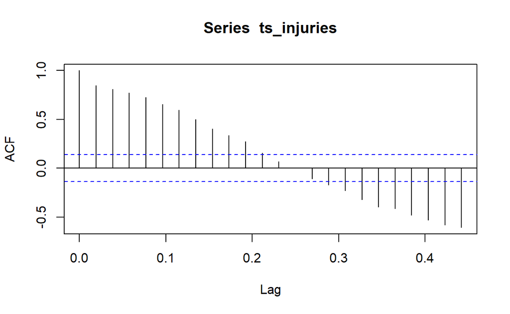

```
Series: ts_injuries
ARIMA(0,1,3)(0,1,1)[52]

Coefficients:
          ma1     ma2      ma3     sma1
      -0.6902  0.0121  -0.2195  -0.5122
s.e.   0.0831  0.1001   0.0821   0.1416

sigma^2 estimated as 337.8:  log likelihood=-651.65
AIC=1313.3   AICc=1313.71   BIC=1328.31

Training set error measures:
                    ME     RMSE      MAE       MPE     MAPE      MASE
Training set -1.589831 15.57204 10.44011 -4.812162 13.84195 0.5500583
                    ACF1
Training set -0.01016123
```